# Business decisions

Goal: To prioritize the hypotheses that may boost revenue, launch an A/B test, and analyze the results. Make a business decision based on the experiment results.

Step 1. General Information and preprocessing  
Step 2. Prioritizing Hypotheses  
Step 3. A/B Test Analysis:

- 1. Cumulative revenue by group
- 2. Cumulative average order size by group
- 3. Relative difference in cumulative average order size between the groups
- 4. Groups conversion rate
- 5. Scatter chart of the number of orders per user
- 6. Scatter chart of order prices
- 7. 95th and 99th percentiles for the number of orders per user
- 8. 95th and 99th percentiles of order prices
- 9. Statistical significance of the difference in conversion between the groups for the raw data
- 10. Statistical significance of the difference in average order size between the groups for the raw data
- 11. Statistical significance of the difference in conversion between the groups for the filtered data
- 12. Statistical significance of the difference in average order size between the groups for the filtered data
- 13. A desision supporting graphs and calculations

Step 4. Overall project conclusion and desision

## Step 1. General Information and preprocessing

```python
import pandas as pd
import numpy as np
import matplotlib.pyplot as plt
from scipy import stats as st
import seaborn as sns
import random
hyp_df = pd.read_csv('/datasets/hypotheses_us.csv', sep=';')
orders_df = pd.read_csv('/datasets/orders_us.csv')
visits_df = pd.read_csv('/datasets/visits_us.csv')
orders_df.head()
```

|  | transactionId | visitorId | date | revenue | group |
| --- | --- | --- | --- | --- | --- |
| 0 | 3667963787 | 3312258926 | 2019-08-15 | 30.4 | B |
| 1 | 2804400009 | 3642806036 | 2019-08-15 | 15.2 | B |
| 2 | 2961555356 | 4069496402 | 2019-08-15 | 10.2 | A |
| 3 | 3797467345 | 1196621759 | 2019-08-15 | 155.1 | B |
| 4 | 2282983706 | 2322279887 | 2019-08-15 | 40.5 | B |

```python
orders_df.duplicated().value_counts()
```

```
False    1197
dtype: int64
```

```python
orders_df.group.value_counts()
```

```
B    640
A    557
Name: group, dtype: int64
```

`The groups are uneven, but that's ok for the test since they large enough.`

```python
orders_df.columns = ['order_id', 'user_id', 'date', 'revenue', 'group']
```

```python
orders_df.describe()
```

|  | order_id | user_id | revenue |
| --- | --- | --- | --- |
| count | 1.197000e+03 | 1.197000e+03 | 1197.000000 |
| mean | 2.155621e+09 | 2.165960e+09 | 131.491646 |
| std | 1.229085e+09 | 1.236014e+09 | 603.004729 |
| min | 1.062393e+06 | 5.114589e+06 | 5.000000 |
| 25% | 1.166776e+09 | 1.111826e+09 | 20.800000 |
| 50% | 2.145194e+09 | 2.217985e+09 | 50.200000 |
| 75% | 3.237740e+09 | 3.177606e+09 | 130.400000 |
| max | 4.293856e+09 | 4.283872e+09 | 19920.400000 |

`There are some extreme values in orders revenue.`

```python
renegates = orders_df.groupby('user_id')['group'].nunique().reset_index().query('group > 1')
renegates.shape
```

```
(58, 2)
```

```python
print("{0:.2%}".format(renegates.shape[0]/orders_df.shape[0]))
```

```
4.85%
```

```python
renegates.head()
```

|  | user_id | group |
| --- | --- | --- |
| 2 | 8300375 | 2 |
| 44 | 199603092 | 2 |
| 51 | 232979603 | 2 |
| 55 | 237748145 | 2 |
| 66 | 276558944 | 2 |

```python
renegates_list = renegates['user_id'].tolist()
renegates_dates = orders_df.query('user_id == @renegates_list')[['date', 'group']]
renegates_dates = renegates_dates.groupby(['group', 'date']).agg({'date' : 'count'})
renegates_dates.columns = ['count']
renegates_dates = renegates_dates.reset_index()
```

```python
def remove_from_visits(date, group): #reduce daily visits by the amount of "renegate" users for the same group same day
    if (len(renegates_dates.query('date == @date and group == @group')) != 0):
        return (visits_df.query('date == @date and group == @group')['visits'].iloc[0]
                - renegates_dates.query('date == @date and group == @group')['count'].iloc[0])
    else:
        return visits_df.query('date == @date and group == @group')['visits'].iloc[0]
visits_df['visits'] = visits_df.apply(lambda x: remove_from_visits(x['date'], x['group']), axis=1)
```

```python
orders_df = orders_df.drop(renegates.index)
```

```python
orders_df['date'] = pd.to_datetime(orders_df['date'])
orders_df.info()
```

```
<class 'pandas.core.frame.DataFrame'>
Int64Index: 1139 entries, 0 to 1196
Data columns (total 5 columns):
order_id    1139 non-null int64
user_id     1139 non-null int64
date        1139 non-null datetime64[ns]
revenue     1139 non-null float64
group       1139 non-null object
dtypes: datetime64[ns](1), float64(1), int64(2), object(1)
memory usage: 53.4+ KB
```

`Check for date integrity:`

```python
orders_df.sort_values(by=['group','date']).groupby(
    ['group', 'date'])['order_id'].count().reset_index()['date'].diff().dt.days.reset_index().query('date != 1')
```

|  | index | date |
| --- | --- | --- |
| 0 | 0 | NaN |
| 31 | 31 | -30.0 |

```python
visits_df.head()
```

|  | date | group | visits |
| --- | --- | --- | --- |
| 0 | 2019-08-01 | A | 718 |
| 1 | 2019-08-02 | A | 618 |
| 2 | 2019-08-03 | A | 507 |
| 3 | 2019-08-04 | A | 712 |
| 4 | 2019-08-05 | A | 753 |

```python
visits_df.describe()
```

|  | visits |
| --- | --- |
| count | 62.000000 |
| mean | 604.370968 |
| std | 113.910841 |
| min | 361.000000 |
| 25% | 529.250000 |
| 50% | 621.000000 |
| 75% | 707.500000 |
| max | 768.000000 |

```python
visits_df['date'] = pd.to_datetime(visits_df['date'])
visits_df.info()
```

```
<class 'pandas.core.frame.DataFrame'>
RangeIndex: 62 entries, 0 to 61
Data columns (total 3 columns):
date      62 non-null datetime64[ns]
group     62 non-null object
visits    62 non-null int64
dtypes: datetime64[ns](1), int64(1), object(1)
memory usage: 1.6+ KB
```

`Check for date integrity:`

```python
visits_df.sort_values(['group', 'date'])['date'].diff().dt.days.reset_index().query('date != 1')
```

|  | index | date |
| --- | --- | --- |
| 0 | 0 | NaN |
| 31 | 31 | -30.0 |

```python
visits_df['group'].value_counts()
```

```
A    31
B    31
Name: group, dtype: int64
```

```python
visits_df.duplicated().value_counts()
```

```
False    62
dtype: int64
```

## Step 2. Prioritizing Hypotheses

```python
hyp_df.sort_values(by='Effort', ascending=False).style.set_properties(subset=['Hypothesis'], **{'width-min': '300px'})
```

|  | Hypothesis | Reach | Impact | Confidence | Effort |
| --- | --- | --- | --- | --- | --- |
| 1 | Launch your own delivery service. This will shorten delivery time | 2 | 5 | 4 | 10 |
| 3 | Change the category structure. This will increase conversion since users will find the products they want more quickly | 8 | 3 | 3 | 8 |
| 0 | Add two new channels for attracting traffic. This will bring 30% more users | 3 | 10 | 8 | 6 |
| 7 | Add a subscription form to all the main pages. This will help you compile a mailing list | 10 | 7 | 8 | 5 |
| 8 | Launch a promotion that gives users discounts on their birthdays | 1 | 9 | 9 | 5 |
| 2 | Add product recommendation blocks to the store's site. This will increase conversion and average purchase size | 8 | 3 | 7 | 3 |
| 5 | Add a customer review page. This will increase the number of orders | 3 | 2 | 2 | 3 |
| 6 | Show banners with current offers and sales on the main page. This will boost conversion | 5 | 3 | 8 | 3 |
| 4 | Change the background color on the main page. This will increase user engagement | 3 | 1 | 1 | 1 |

```python
hyp_df['ICE'] = (hyp_df['Impact']*hyp_df['Confidence'])/hyp_df['Effort']
hyp_df['RICE'] = (hyp_df['Reach']*hyp_df['Impact']*hyp_df['Confidence'])/hyp_df['Effort']
ice = hyp_df[['Hypothesis', 'ICE', 'RICE']].sort_values(by='ICE', ascending=False).reset_index()
ice
```

|  | index | Hypothesis | ICE | RICE |
| --- | --- | --- | --- | --- |
| 0 | 8 | Launch a promotion that gives users discounts ... | 16.200000 | 16.2 |
| 1 | 0 | Add two new channels for attracting traffic. T... | 13.333333 | 40.0 |
| 2 | 7 | Add a subscription form to all the main pages.... | 11.200000 | 112.0 |
| 3 | 6 | Show banners with current offers and sales on ... | 8.000000 | 40.0 |
| 4 | 2 | Add product recommendation blocks to the store... | 7.000000 | 56.0 |
| 5 | 1 | Launch your own delivery service. This will sh... | 2.000000 | 4.0 |
| 6 | 5 | Add a customer review page. This will increase... | 1.333333 | 4.0 |
| 7 | 3 | Change the category structure. This will incre... | 1.125000 | 9.0 |
| 8 | 4 | Change the background color on the main page. ... | 1.000000 | 3.0 |

```python
rice = ice[['Hypothesis', 'ICE', 'RICE']].sort_values(by='RICE', ascending=False).reset_index()
```

```python
p_c = -(rice.index - rice['index']).to_frame()
p_c.columns = ['position change']
rice = rice.join(p_c)
rice = rice.drop('index', axis=1)
rice
```

|  | Hypothesis | ICE | RICE | position change |
| --- | --- | --- | --- | --- |
| 0 | Add a subscription form to all the main pages.... | 11.200000 | 112.0 | 2 |
| 1 | Add product recommendation blocks to the store... | 7.000000 | 56.0 | 3 |
| 2 | Add two new channels for attracting traffic. T... | 13.333333 | 40.0 | -1 |
| 3 | Show banners with current offers and sales on ... | 8.000000 | 40.0 | 0 |
| 4 | Launch a promotion that gives users discounts ... | 16.200000 | 16.2 | -4 |
| 5 | Change the category structure. This will incre... | 1.125000 | 9.0 | 2 |
| 6 | Launch your own delivery service. This will sh... | 2.000000 | 4.0 | -1 |
| 7 | Add a customer review page. This will increase... | 1.333333 | 4.0 | -1 |
| 8 | Change the background color on the main page. ... | 1.000000 | 3.0 | 0 |

`In the column 'position change' of hypothesis in RICE reelative to ICE.`

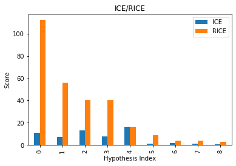

```python
ax = rice[['ICE', 'RICE']].plot(kind='bar', title='ICE/RICE')
ax.set_xlabel('Hypothesis Index')
ax.set_ylabel('Score')
```

#### Conclusion:

Since RICE takes into account the Reach parameter, the prioritization changed. Hypotheses with similar Effort but smaller Reach will have lower priority. Considering Reach automatically drops the birthday hypothesis from the first position on ICE to fifth on RICE - the Reach is very low, hence the outcome in revenue will be low and may be the company should focus on those hypotheses which may improve revenue as much as possible, with reasonable effort. Nevertheless, this drop was the biggest of them all, most of the changes are not that big, and RICE just looks more precise in prioritization, taking into account more factors. So using RICE is justified when company needs the changes to affect maximum amount of customers.

## Step 3. A/B Test Analysis

- 1. Graph cumulative revenue by group. Make conclusions and conjectures.

```python
datesGroups = orders_df[['date','group']].drop_duplicates()
```

```python
datesGroups = orders_df[['date','group']].drop_duplicates()

ordersAggregated = (datesGroups.apply(lambda x: orders_df[np.logical_and(
    orders_df['date'] <= x['date'], orders_df['group'] == x['group'])].agg(
    {'date' : 'max', 'group' : 'max', 'order_id' : 'nunique',
     'user_id' : 'nunique', 'revenue' : 'sum'}), axis=1).sort_values(by=['date','group']))




visitorsAggregated = datesGroups.apply(
    lambda x: visits_df[np.logical_and(visits_df['date'] <= x['date'], visits_df['group'] == x['group'])].agg(
    {'date' : 'max', 'group' : 'max', 'visits' : 'sum'}), axis=1).sort_values(by=['date','group'])
```

```python
cumulativeData = ordersAggregated.merge(visitorsAggregated, left_on=['date', 'group'], right_on=['date', 'group'])
cumulativeData.columns = ['date', 'group', 'orders', 'buyers', 'revenue', 'visitors']
```

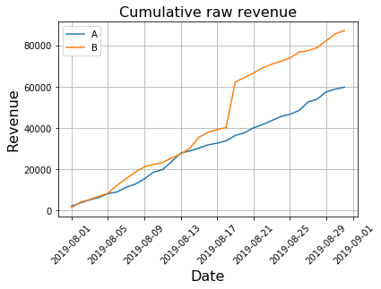

```python
cumulativeRevenueA = cumulativeData[cumulativeData['group']=='A'][['date','revenue', 'orders']]

cumulativeRevenueB = cumulativeData[cumulativeData['group']=='B'][['date','revenue', 'orders']]

plt.plot(cumulativeRevenueA['date'], cumulativeRevenueA['revenue'], label='A')
plt.plot(cumulativeRevenueB['date'], cumulativeRevenueB['revenue'], label='B')
plt.xticks(rotation=45)
plt.grid(b='on')
plt.title('Cumulative raw revenue', fontsize=16)
plt.xlabel('Date', fontsize=16)
plt.ylabel('Revenue', fontsize=16)
plt.legend()
```

- 1. Graph cumulative average order size by group. Make conclusions and conjectures.

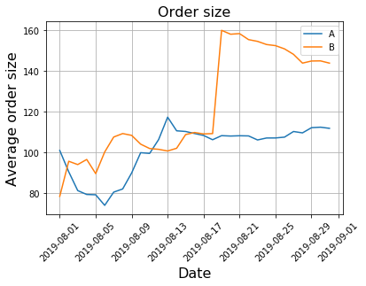

```python
plt.plot(cumulativeRevenueA['date'], cumulativeRevenueA['revenue']/cumulativeRevenueA['orders'], label='A')
plt.plot(cumulativeRevenueB['date'], cumulativeRevenueB['revenue']/cumulativeRevenueB['orders'], label='B')
plt.xticks(rotation=45)
plt.grid(b='on')
plt.legend()
plt.title('Order size', fontsize=16)
plt.xlabel('Date', fontsize=16)
plt.ylabel('Average order size', fontsize=16)
```

- 1. Graph the relative difference in cumulative average order size for group B compared with group A. Make conclusions and conjectures.

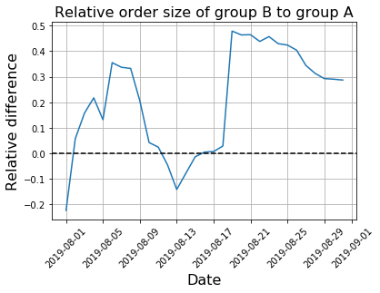

```python
mergedCumulativeRevenue = cumulativeRevenueA.merge(cumulativeRevenueB,
                                                   left_on='date', right_on='date', how='left', suffixes=['A', 'B'])

plt.plot(mergedCumulativeRevenue['date'],
         (mergedCumulativeRevenue['revenueB']/mergedCumulativeRevenue['ordersB'])
         /(mergedCumulativeRevenue['revenueA']/mergedCumulativeRevenue['ordersA'])-1)

plt.axhline(y=0, color='black', linestyle='--')
plt.xticks(rotation=45)
plt.grid(b='on')
plt.title('Relative order size of group B to group A', fontsize=16)
plt.xlabel('Date', fontsize=16)
plt.ylabel('Relative difference', fontsize=16)
```

`The difference betweeen average order sizes is never even, with a lot of spikes. The decline stabilizes only towards the end of the experiment. This indicates some big orders. But in general, it looks like for group B order size was higher.`

- 1. Calculate each group's conversion rate as the ratio of orders to the number of visits for each day. Plot the daily conversion rates of the two groups and describe the difference. Draw conclusions and make conjectures.

```
[Timestamp('2019-08-01 00:00:00'), Timestamp('2019-08-31 00:00:00'), 0, 0.05]
```

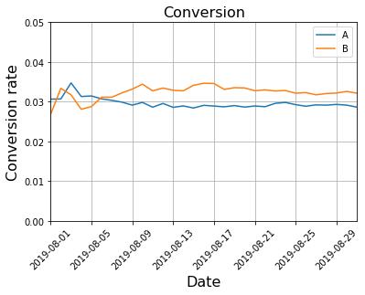

```python
cumulativeData['conversion'] = cumulativeData['orders']/cumulativeData['visitors']

cumulativeDataA = cumulativeData[cumulativeData['group']=='A']
cumulativeDataB = cumulativeData[cumulativeData['group']=='B']

plt.plot(cumulativeDataA['date'], cumulativeDataA['conversion'], label='A')
plt.plot(cumulativeDataB['date'], cumulativeDataB['conversion'], label='B')
plt.legend()
plt.grid(b='on')
plt.xticks(rotation=45)
plt.title('Conversion', fontsize=16)
plt.xlabel('Date', fontsize=16)
plt.ylabel('Conversion rate', fontsize=16)
plt.axis([pd.to_datetime('2019.08.01'), pd.to_datetime('2019.08.31'), 0, 0.05])
```

`There were some fluctuations from the beginning to the middle of the experiment. Conversion stabilizes for both groups in the second half of the experiment. For group B, the conversion was higher for the entire experiment, except for the beginning.`

`Let's plot a relative difference graph for the cumulative conversion rates:`

```
No handles with labels found to put in legend.
```

```
[Timestamp('2019-08-02 00:00:00'), Timestamp('2019-08-31 00:00:00'), -0.5, 0.5]
```

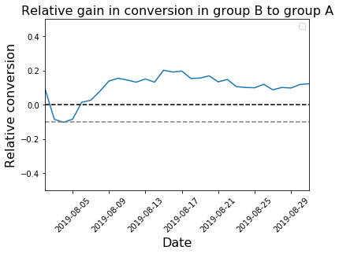

```python
mergedCumulativeConversions = cumulativeDataA[['date','conversion']].merge(cumulativeDataB[['date','conversion']], left_on='date', right_on='date', how='left', suffixes=['A', 'B'])

plt.plot(mergedCumulativeConversions['date'], mergedCumulativeConversions['conversionB']/mergedCumulativeConversions['conversionA']-1)
plt.legend()

plt.axhline(y=0, color='black', linestyle='--')
plt.axhline(y=-0.1, color='grey', linestyle='--')
plt.xticks(rotation=45)
plt.title('Relative gain in conversion in group B to group A', fontsize=16)
plt.xlabel('Date', fontsize=16)
plt.ylabel('Relative conversion', fontsize=16)
plt.axis([pd.to_datetime('2019-08-02'), pd.to_datetime('2019-08-31'), -0.5, 0.5])
```

`The graph describes how higher the conversion of group B was relative to A (based on the data with outliers).`

- 1. Plot a scatter chart of the number of orders per user. Make conclusions and conjectures.

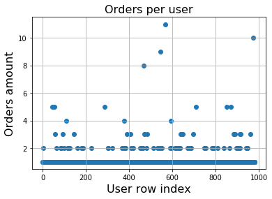

```python
ordersByUsers = orders_df.groupby('user_id', as_index=False)['order_id'].count()#.plot(kind='scatter')
x_values = pd.Series(range(0, len(ordersByUsers)))
plt.grid(b='on')
plt.scatter(x_values, ordersByUsers['order_id'])
plt.title('Orders per user', fontsize=16)
plt.xlabel('User row index', fontsize=16)
plt.ylabel('Orders amount', fontsize=16)
```

`Most of the users place one order, less often two. There are some extreme values, up to 11 orders, which should be filtered.`

- 1. Plot a scatter chart of order prices. Make conclusions and conjectures.

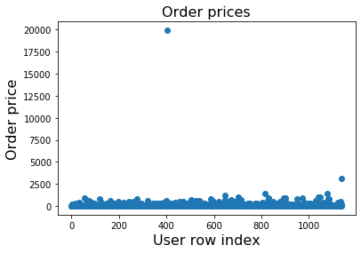

```python
x_values = pd.Series(range(0, len(orders_df['revenue'])))
plt.scatter(x_values, orders_df['revenue'])
plt.title('Order prices', fontsize=16)
plt.xlabel('User row index', fontsize=16)
plt.ylabel('Order price', fontsize=16)
```

```
[0, 1139, 0, 2500]
```

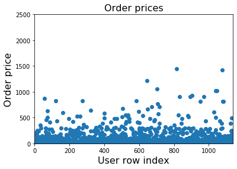

```python
plt.scatter(x_values, orders_df['revenue'])
plt.title('Order prices', fontsize=16)
plt.xlabel('User row index', fontsize=16)
plt.ylabel('Order price', fontsize=16)
plt.axis([0, len(x_values), 0, 2500])
```

`There is an extreme order for 20000, but for almost all the other orders the limit is around 500. Extreme values should be cleared.`

- 1. Calculate the 95th and 99th percentiles for the number of orders per user. Define the point at which a data point becomes an anomaly.

```python
np.percentile(ordersByUsers['order_id'], [95, 99])
```

```
array([2.  , 4.18])
```

```python
print(len(ordersByUsers[ordersByUsers['order_id'] > 2]), 'out of', len(ordersByUsers), 'are anomalies')
```

```
28 out of 983 are anomalies
```

`More than two orders per user may be considered an anomaly.`

- 1. Calculate the 95th and 99th percentiles of order prices. Define the point at which a data point becomes an anomaly.

```python
np.percentile(orders_df['revenue'], [95, 99])
```

```
array([426.86 , 891.124])
```

```python
print(len(orders_df[orders_df['revenue'] > 426]), 'out of', len(orders_df), 'are anomalies')
```

```
57 out of 1139 are anomalies
```

`Orders bigger than 426 may be considered an anomaly.`

- 1. Find the statistical significance of the difference in conversion between the groups using the raw data. Make conclusions and conjectures.

```python
ordersByUsersA = orders_df[orders_df['group']=='A'].groupby('user_id', as_index=False).agg({'order_id' : pd.Series.nunique})
ordersByUsersA.columns = ['user_id', 'orders']

ordersByUsersB = orders_df[orders_df['group']=='B'].groupby('user_id', as_index=False).agg({'order_id' : pd.Series.nunique})
ordersByUsersB.columns = ['user_id', 'orders']
```

```python
sampleA = pd.concat([ordersByUsersA['orders'],
                     pd.Series(0, index=np.arange(visits_df[visits_df['group']=='A']['visits'].sum() -
                                                  len(ordersByUsersA['orders'])), name='orders')],axis=0)

sampleB = pd.concat([ordersByUsersB['orders'],
                     pd.Series(0, index=np.arange(visits_df[visits_df['group']=='B']['visits'].sum() -
                                                  len(ordersByUsersB['orders'])), name='orders')],axis=0)
```

##### Testing:

Let's compare the raw data conversion between groups:  
$H_{0}$ - There is no statistically significant difference between conversions of groups.  
$H_{a}$ - The conversion of group B is different from conversion of group A.

```python
p = st.mannwhitneyu(sampleA, sampleB).pvalue
print('p-value:', "{0:.3f}".format(p))
print('Relative conversion difference:', "{0:.3f}".format(sampleB.mean()/sampleA.mean()-1))
if (p > 0.05):
    print("We can't reject the null hypothesis.")
else:
    print('We reject the null hypothesis.')
```

```
p-value: 0.019
Relative conversion difference: 0.122
We reject the null hypothesis.
```

```
Based on a raw data, there is a difference between conversion in groups A and B.
P-value returned by Mann-Whitney test is 0.019 which is lower than 0.05. The relative gain of conversion in group B is 12.2%.
```

- 1. Find the statistical significance of the difference in average order size between the groups using the raw data. Make conclusions and conjectures.

##### Testing:

Let's compare the average order size of two groups based on raw data:  
$H_{0}$ - There is no statistically significant difference between average order size of the groups.  
$H_{a}$ - The average order size of group B is different from average order size of group A.

```python
p = st.mannwhitneyu(orders_df[orders_df['group']=='A']['revenue'], orders_df[orders_df['group']=='B']['revenue'])[1]
print('p-value:', "{0:.3f}".format(p))
print('Average order size relative difference:', "{0:.3f}".format(orders_df[orders_df['group']=='B']['revenue'].mean()/orders_df[orders_df['group']=='A']['revenue'].mean()-1))
if (p > 0.05):
    print("We can't reject the null hypothesis.")
else:
    print('We reject the null hypothesis.')
```

```
p-value: 0.349
Average order size relative difference: 0.287
We can't reject the null hypothesis.
```

`Based on a raw data, there is no difference in order size between groups A and B. P-value is 0.349 much higher than 0.05 treshold, we can't reject the null hypothesis that there's no statistically significant difference in order size between the groups. The realtive gain for group B is 28.7%.`

- 1. Find the statistical significance of the difference in conversion between the groups using the filtered data. Make conclusions and conjectures.

```python
usersWithManyOrders = pd.concat([ordersByUsersA[ordersByUsersA['orders'] > 2]['user_id'], ordersByUsersB[ordersByUsersB['orders'] > 2]['user_id']], axis = 0)
usersWithExpensiveOrders = orders_df[orders_df['revenue'] > 426]['user_id']
abnormalUsers = pd.concat([usersWithManyOrders, usersWithExpensiveOrders], axis = 0).drop_duplicates().sort_values()
print(abnormalUsers.shape)
abnormalUsers.head(5)
```

```
(72,)
```

```
1099    148427295
18      199603092
928     204675465
23      237748145
36      249864742
Name: user_id, dtype: int64
```

```python
sampleAFiltered = pd.concat([ordersByUsersA[np.logical_not(ordersByUsersA['user_id'].isin(abnormalUsers))]['orders'],
                             pd.Series(0, index=np.arange(visits_df[visits_df['group']=='A']['visits'].sum() -
                                                          len(ordersByUsersA['orders'])),name='orders')],axis=0)

sampleBFiltered = pd.concat([ordersByUsersB[np.logical_not(ordersByUsersB['user_id'].isin(abnormalUsers))]['orders'],
                             pd.Series(0, index=np.arange(visits_df[visits_df['group']=='B']['visits'].sum() -
                                                          len(ordersByUsersB['orders'])),name='orders')],axis=0)
```

##### Testing:

Let's compare the filtered data conversion between groups:  
$H_{0}$ - There is no statistically significant difference between conversions of groups.  
$H_{a}$ - The conversion of group B is different from conversion of group A.

```python
p = st.mannwhitneyu(sampleAFiltered, sampleBFiltered)[1]
print('p-value', "{0:.3f}".format(p))
print('Relative conversion difference:', "{0:.3f}".format(sampleBFiltered.mean()/sampleAFiltered.mean()-1))
if (p > 0.05):
    print("We can't reject the null hypothesis.")
else:
    print('We reject the null hypothesis.')
```

```
p-value 0.017
Relative conversion difference: 0.150
We reject the null hypothesis.
```

`Based on a clean data, there is a difference between conversion in groups. P-value is 0.017, lower than 0.05. The relative gain is 15%.`

- 1. Find the statistical significance of the difference in average order size between the groups using the filtered data. Make conclusions and conjectures.

##### Testing:

Let's compare the average order size between groups based on filtered data:  
$H_{0}$ - There is no statistically significant difference between average order size of the groups.  
$H_{a}$ - The average order size of group B is different from average order size of group A.

```python
p = (st.mannwhitneyu(orders_df[np.logical_and(orders_df['group']=='A',
        np.logical_not(orders_df['user_id'].isin(abnormalUsers)))]['revenue'], orders_df[np.logical_and(
        orders_df['group']=='B', np.logical_not(orders_df['user_id'].isin(abnormalUsers)))]['revenue'])[1])

print('p-value:', "{0:.3f}".format(p))
print('Average order size relative difference:', "{0:.3f}".format(orders_df[np.logical_and(orders_df['group']=='B',
                                                np.logical_not(orders_df['user_id'].isin(abnormalUsers)))]
                       ['revenue'].mean() / orders_df[np.logical_and(
        orders_df['group']=='A', np.logical_not(orders_df['user_id'].isin(abnormalUsers)))]['revenue'].mean() - 1))
if (p > 0.05):
    print("We can't reject the null hypothesis.")
else:
    print('We reject the null hypothesis.')
```

```
p-value: 0.340
Average order size relative difference: -0.026
We can't reject the null hypothesis.
```

- 1. Make a decision based on the test results. The possible decisions are: 1. Stop the test, consider one of the groups the leader. 2. Stop the test, conclude that there is no difference between the groups. 3. Continue the test.

```
[Timestamp('2019-08-01 00:00:00'), Timestamp('2019-08-31 00:00:00'), 0, 0.05]
```

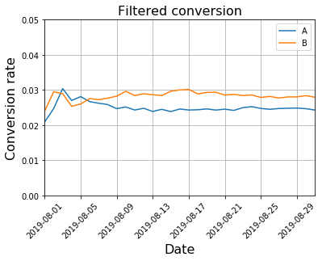

```python
abnormalUsers_list = pd.Series.tolist(abnormalUsers)
orders_filtered = orders_df.query('user_id != @abnormalUsers_list')

ordersAggregated_filtered = (datesGroups.apply(lambda x: orders_filtered[np.logical_and(
    orders_filtered['date'] <= x['date'], orders_filtered['group'] == x['group'])].agg(
    {'date' : 'max', 'group' : 'max', 'order_id' : 'nunique',
     'user_id' : 'nunique', 'revenue' : 'sum'}), axis=1).sort_values(by=['date','group']))

ordersAggregated_filtered_A = ordersAggregated_filtered.query('group == "A"')
ordersAggregated_filtered_B = ordersAggregated_filtered.query('group == "B"')

cumulativeData_f = ordersAggregated_filtered.merge(visitorsAggregated, left_on=['date', 'group'], right_on=['date', 'group'])
cumulativeData_f.columns = ['date', 'group', 'orders', 'buyers', 'revenue', 'visitors']

cumulativeData_f['conversion'] = cumulativeData_f['orders']/cumulativeData_f['visitors']

cumulativeDataA_f = cumulativeData_f[cumulativeData_f['group']=='A']
cumulativeDataB_f = cumulativeData_f[cumulativeData_f['group']=='B']

plt.plot(cumulativeDataA_f['date'], cumulativeDataA_f['conversion'], label='A')
plt.plot(cumulativeDataB_f['date'], cumulativeDataB_f['conversion'], label='B')
plt.legend()
plt.grid(b='on')
plt.xticks(rotation=45)
plt.title('Filtered conversion', fontsize=16)
plt.xlabel('Date', fontsize=16)
plt.ylabel('Conversion rate', fontsize=16)
plt.axis([pd.to_datetime('2019.08.01'), pd.to_datetime('2019.08.31'), 0, 0.05])
```

```
[Timestamp('2019-08-02 00:00:00'), Timestamp('2019-08-31 00:00:00'), -0.5, 0.5]
```

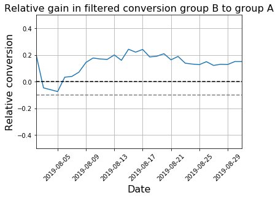

```python
mergedCumulativeConversions_f = cumulativeDataA_f[['date','conversion']].merge(
    cumulativeDataB_f[['date','conversion']], left_on='date', right_on='date', how='left', suffixes=['A', 'B'])

plt.plot(mergedCumulativeConversions_f['date'],
         mergedCumulativeConversions_f['conversionB']/mergedCumulativeConversions_f['conversionA']-1)
plt.axhline(y=0, color='black', linestyle='--')
plt.axhline(y=-0.1, color='grey', linestyle='--')
plt.xticks(rotation=45)
plt.grid(b='on')
plt.title('Relative gain in filtered conversion group B to group A', fontsize=16)
plt.xlabel('Date', fontsize=16)
plt.ylabel('Relative conversion', fontsize=16)
plt.axis([pd.to_datetime('2019-08-02'), pd.to_datetime('2019-08-31'), -0.5, 0.5])
```

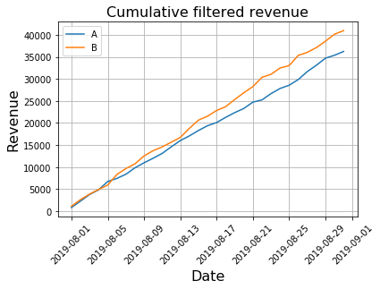

```python
plt.plot(ordersAggregated_filtered_A['date'], ordersAggregated_filtered_A['revenue'], label='A')

plt.plot(ordersAggregated_filtered_B['date'], ordersAggregated_filtered_B['revenue'], label='B')
plt.xticks(rotation=45)
plt.title('Cumulative filtered revenue', fontsize=16)
plt.xlabel('Date', fontsize=16)
plt.ylabel('Revenue', fontsize=16)
plt.grid(b='on')
plt.legend()
```

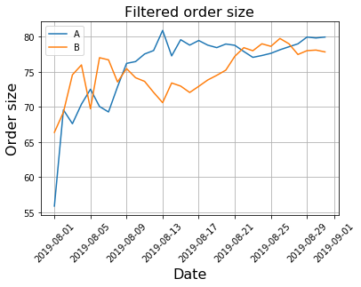

```python
plt.plot(ordersAggregated_filtered_A['date'],
         ordersAggregated_filtered_A['revenue']/ordersAggregated_filtered_A['order_id'], label='A')
plt.plot(ordersAggregated_filtered_B['date'],
         ordersAggregated_filtered_B['revenue']/ordersAggregated_filtered_B['order_id'], label='B')
plt.xticks(rotation=45)
plt.grid(b='on')
plt.title('Filtered order size', fontsize=16)
plt.xlabel('Date', fontsize=16)
plt.ylabel('Order size', fontsize=16)
plt.legend()
```

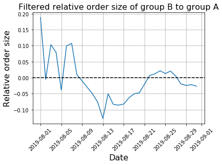

```python
mergedCumulativeRevenue_f = cumulativeDataA_f.merge(cumulativeDataB_f,
                                                   left_on='date', right_on='date', how='left', suffixes=['A', 'B'])
plt.plot(mergedCumulativeRevenue_f['date'],
         (mergedCumulativeRevenue_f['revenueB']/mergedCumulativeRevenue_f['ordersB'])
         /(mergedCumulativeRevenue_f['revenueA']/mergedCumulativeRevenue_f['ordersA'])-1)
plt.axhline(y=0, color='black', linestyle='--')
plt.xticks(rotation=45)
plt.title('Filtered relative order size of group B to group A', fontsize=16)
plt.xlabel('Date', fontsize=16)
plt.ylabel('Relative order size', fontsize=16)
plt.grid(b='on')
```

### Conclusion:

The conducted experiment showed that there is an statistically significant improvement in conversion rate in group B relative to group A by 15%. To improve overall conversion, we should apply changes made for group B to all our users. However, there is no statistically significant difference between order size in groups, so it seems the changes didn't affect order sizes.  
We should stop the test and consider group B the leader in conversion.